# US Inaugural Speeches - Focus on presidents having done two terms in office

What is the mindset of a reelected president? Is there any trend or pattern that can be identified among reelected presidents?

Marie Schiltz

This is an *Interactive* [R Markdown](http://rmarkdown.rstudio.com) Notebook. It generates an HTML notebook that would allow users to interactively explore your analysis results.

This analysis is based on the inaugural speeches of all the US presidents since George Washington in 1789.  
With this study, I would like to determine what is the mindset of a president beginning his second term in office. Is there any difference with a president beginning his first term? How a president appointed for the second time (and the last one) begin his new term? For this reason, the study will focus on presidents who have done two terms in office.  
I will try to answer the following questions:  
* Is the president more confident during the second inaugural speech?  
* Are the subjects of his speech the same?  
* Is he more optimistic or more realistic?  
Of course, I’ll adapt my study depending on what I find during the process.

[Note] * Don’t forget to download the entire folder provided as each subfolder is important. * This notebook contaisn shiny Apps, that’s why I didn’t publish any .html file, you will need to run it from RStudio * Run Time: Around 15 minutes

## Step 0 - Install and load libraries

```r
packages.used=c("tidytext", "dplyr", "tm", "ggplot2", "wordcloud", "rvest",
                "tibble", "qdap", "sentimentr", "gplots", "syuzhet",
                "factoextra", "beeswarm", "scales", "RColorBrewer", "RANN",
                "topicmodels", "splitstackshape", "tidyr", "shiny", "gridExtra",
                "grid")

# check packages that need to be installed.
packages.needed=setdiff(packages.used, intersect(installed.packages()[,1],
                                                 packages.used))

# install additional packages
if(length(packages.needed)>0){
  install.packages(packages.needed, dependencies = TRUE,
                   repos='http://cran.us.r-project.org')
}

# load packages
library("tidytext")
library("dplyr")
library("tm")
library("ggplot2")
library("wordcloud")
library("rvest")
library("tibble")
library("qdap")
library("sentimentr")
library("gplots")
library("syuzhet")
library("factoextra")
library("beeswarm")
library("scales")
library("RColorBrewer")
library("RANN")
library("topicmodels")
library("splitstackshape")
library("tidyr")
library("shiny")
library("gridExtra")
library("grid")

# source functions
source("../lib/processing.R")
source("../lib/displaying.R")
```

This notebook was prepared with the following environmental settings.

```r
print(R.version)
```

```
##                _
## platform       x86_64-apple-darwin13.4.0
## arch           x86_64
## os             darwin13.4.0
## system         x86_64, darwin13.4.0
## status
## major          3
## minor          3.2
## year           2016
## month          10
## day            31
## svn rev        71607
## language       R
## version.string R version 3.3.2 (2016-10-31)
## nickname       Sincere Pumpkin Patch
```

## Step 1 - Read in the speeches

```r
folder.path = "../data/InauguralSpeeches/"
speeches = list.files(path = folder.path, pattern = "*.txt")
ff.all <- Corpus(DirSource(folder.path))
```

## Step 2 - Text processing

For the speeches, we remove extra white space, convert all letters to the lower case, remove [stop words](https://github.com/arc12/Text-Mining-Weak-Signals/wiki/Standard-set-of-english-stopwords), removed empty words due to formatting errors, and remove punctuation. Then we compute the [Document-Term Matrix (DTM)](https://en.wikipedia.org/wiki/Document-term_matrix).

```r
# remove white Spaces, transform to lower case, remove stop words, remove empty words and remove punctuation
ff.all<-tm_map(ff.all, stripWhitespace)
ff.all<-tm_map(ff.all, content_transformer(tolower))
ff.all<-tm_map(ff.all, removeWords, stopwords("english"))
ff.all<-tm_map(ff.all, removeWords, character(0))
ff.all<-tm_map(ff.all, removePunctuation)

# compute Term-Document Matrix
tdm <- TermDocumentMatrix(ff.all)

# compute Document-Term Matrix
dtm <- DocumentTermMatrix(ff.all)
dtm.tidy <- tidy(dtm)
dtm.all <- summarise(group_by(dtm.tidy, term), sum(count))

# # inspect dtm or tdm
# inspect(tdm[100:105,25:30])
# inspect(dtm[25:27,100:104])
# dim(dtm.idf)

#Note: I am using both tdm and dtm, because it's easier to use one or the other for some applications later on.
```

## Step 3 - compute TF-IDF weighted document-term matrices for individual speeches.

As we would like to identify interesting words for each inaugural speech, we use [TF-IDF](https://en.wikipedia.org/wiki/Tf%E2%80%93idf) to weigh each term within each speech. It highlights terms that are more specific for a particular speech.

```r
# Compute TermDocument Matrix weighted with TF-IDF principle
tdm.idf <- TermDocumentMatrix(ff.all,
                          control = list(weighting = function(x)
                                             weightTfIdf(x, normalize =FALSE),
                                         stopwords = TRUE))

# Compute DocumentTerm Matrix weighted with TF-IDF principle
dtm.idf <- DocumentTermMatrix(ff.all,
                          control = list(weighting = function(x)
                                             weightTfIdf(x, normalize =FALSE),
                                         stopwords = TRUE))
dtm.idf.tidy <- tidy(dtm.idf)
dtm.idf.all <- summarise(group_by(dtm.idf.tidy, term), sum(count))

# # Cast into a Matrix object
# m.tdm.idf.tidy <- tdm.idf.tidy %>%
#   cast_sparse(document, term, count)
```

## Step 4 - Identify presidents who did two terms in office

As discussed earlier, this study will focus on presidents who’ve spent two terms in office. For this reason I will remove from the corpus all other presidents. President Lincoln who did two terms in office is to be kept in this analysis.

Below you’ll find the list of presidents who did two terms in office.

```r
# list of presidents who did two terms in office
prex.out <- substr(speeches, 6, nchar(speeches)-4)
speeches.info <- as.data.frame(prex.out)
speeches.info <- cSplit(speeches.info, "prex.out", "-")
colnames(speeches.info)[1] <- "name"
colnames(speeches.info)[2] <- "term"
speeches.info$prex.out_3 <- NULL

president.list <- as.character(speeches.info[speeches.info$term==2,]$name)
print(president.list)
```

```
##  [1] "AbrahamLincoln"     "AndrewJackson"      "BarackObama"
##  [4] "DwightDEisenhower"  "FranklinDRoosevelt" "GeorgeWashington"
##  [7] "GeorgeWBush"        "JamesMadison"       "JamesMonroe"
## [10] "RichardNixon"       "RonaldReagan"       "ThomasJefferson"
## [13] "UlyssesSGrant"      "WilliamJClinton"    "WilliamMcKinley"
## [16] "WoodrowWilson"
```

## Step 5 - Data processing: Update tables to keep only presidents who were elected twice

```r
# update all dtms tables so that they contain only speeches given by presidents who stayed two terms in office
# see the file processing.R for details about the functions used in this chunk
dtm.tidy <- update.tables(dtm.tidy,president.list)
dtm.idf.tidy <- update.tables(dtm.idf.tidy,president.list)

dtm.all <- summarise(group_by(dtm.tidy, word), count = sum(count))
dtm.idf.all <- summarise(group_by(dtm.idf.tidy, word), count = sum(count))
```

## Step 6 - Word Frequency - Wordcloud

This section is the first visualisation section, I propose you to have a look at some wordclouds. Each time, you will have on the left the wordcloud corresponding on the first inaugural speech and on the right the wordcloud corresponding to the second inaugural speech of the selected president.

Shiny applications not supported in static R Markdown documents

From those wordclouds, one can already identify important topics and differences between the first and second inaugural speeches of each president.

Barack Obama, first speech seems focused on natural catastrophes and employment, while his second speech seems more philosophical (words like “journey” or creed).

In William Clinton speeches, we also find this transition to a second speech talking about a journey and the passing of time (“century”).

Of course, this is not true for all presidents, Reagan speeches use similar lexicons (repetition of the word “weapon”)

However, a wordcloud doesn’t allow us to have an overall appreciation of the speech. One would like to know the overall atmosphere - and to be able to know if the speech is optimistic or not. To do that we will focus on sentiment analysis in the next section.

## Step 7: Sentiment Analysis - Overall score

For each word we will apply sentiment analysis using [NRC sentiment lexion](http://saifmohammad.com/WebPages/NRC-Emotion-Lexicon.htm). “The NRC Emotion Lexicon is a list of English words and their associations with eight basic emotions (anger, fear, anticipation, trust, surprise, sadness, joy, and disgust) and two sentiments (negative and positive). The annotations were manually done by crowdsourcing.”

Note that the tidytext package also contains the sentiments dataset which includes three useful lexicons: - nrc: the one we are using - afinn: assigns a score to each word (the score is between -5 and 5, negative scores indicate negative sentiments) - bing: categorizes words into positive and negative categories One can access those lexicons by using the function get_sentiment()

The goal of this section is to compute an overall score for each speech. Each negative word will be counted negatively and weighted depending on its redundancy - the same will be applied for positive words.

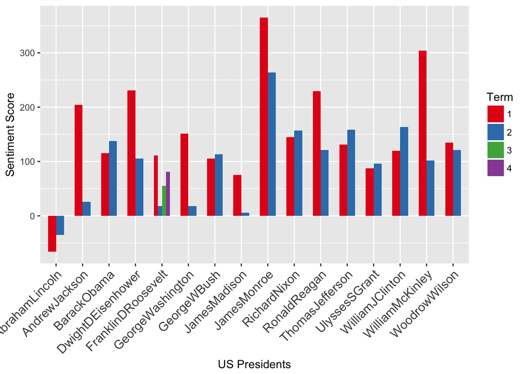

```r
# get sentiments
dtm.idf.sentiment <- inner_join(dtm.idf.tidy,
                                get_sentiments("nrc"),
                                by=c("word"="word"))

# spread sentiments in different columns
dtm.idf.sentiment <- spread(dtm.idf.sentiment, sentiment, count, fill=0)

# compute a sentiment score for each speech
sentiment.score <- mutate(dtm.idf.sentiment, feeling = positive - negative)
sentiment.score <- summarise(group_by(sentiment.score, document, president, term),
                             score = sum(feeling))

c <- ggplot(sentiment.score, aes(x=sentiment.score$president,
                                 y=sentiment.score$score,
                                 fill=sentiment.score$term)) +
  geom_bar(stat="identity", position = "dodge", width=.6) +
  ylab("Sentiment Score") +
  xlab("US Presidents") +
  scale_fill_manual("Term", values=brewer.pal(9,"Set1")) +
  theme(axis.text.x = element_text(angle = 45, size=12, hjust = 1))
c
```

## Step 8 - Sentiment Analysis - Difference between first speech score and second speech score

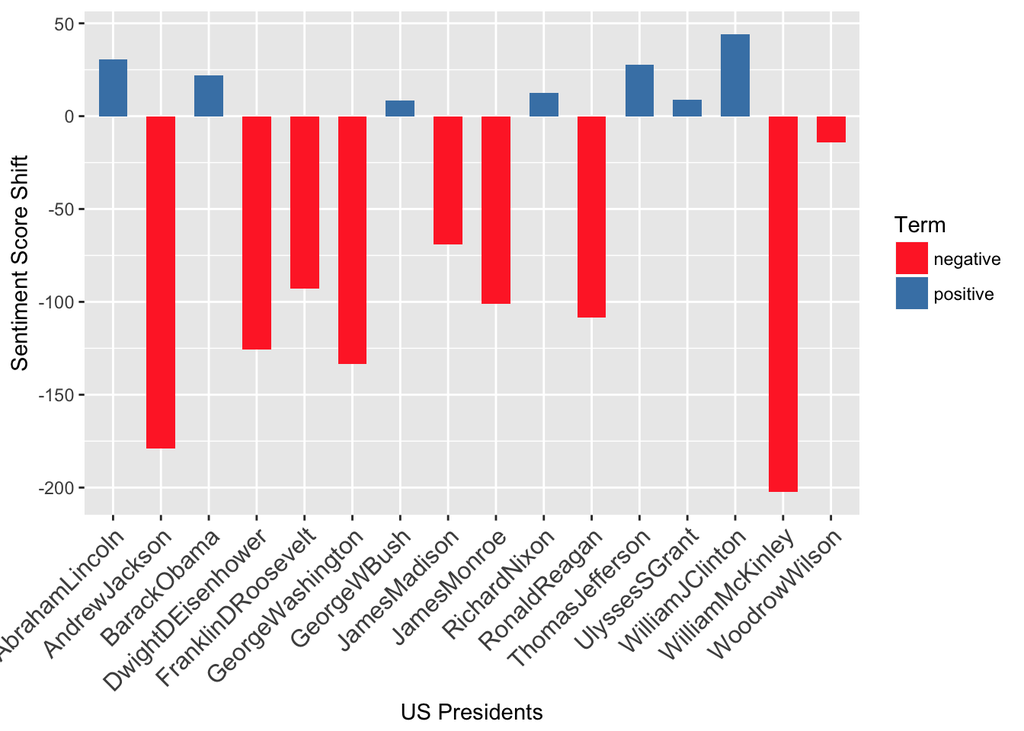

```r
# compute difference between score of speech one and score of speech two
sentiment.score.shift = as.data.frame(matrix(ncol=2, nrow=length(president.list)))
names(sentiment.score.shift)[names(sentiment.score.shift)=="V1"] <- "president"
names(sentiment.score.shift)[names(sentiment.score.shift)=="V2"] <- "score"

for (i in 1:length(president.list)){
  a <- sentiment.score[(sentiment.score$president ==
                         president.list[i] & sentiment.score$term == "1"),"score"]
  b <- sentiment.score[sentiment.score$president ==
                         president.list[i] & sentiment.score$term == "2","score"]
  sentiment.score.shift$score[i] <- -(a-b)
  sentiment.score.shift$president[i] <- president.list[i]
}

# assigne colour depending on the sign of the score
sentiment.score.shift$colour <- ifelse(sentiment.score.shift$score < 0,
                                       "negative","positive")
sentiment.score.shift$score <- as.numeric(sentiment.score.shift$score)

d <- ggplot(sentiment.score.shift, aes(x=sentiment.score.shift$president,
                                       y=sentiment.score.shift$score)) +
  geom_bar(stat="identity", width=.6, aes(fill = colour)) +
  ylab("Sentiment Score Shift") +
  xlab("US Presidents") +
  scale_fill_manual("Term", values=c(positive="steelblue",negative="firebrick1")) +
  theme(axis.text.x = element_text(angle = 45, size=12, hjust = 1))
d
```

Most presidents gave a more negative speech at their second inauguration. What is really important to notice from this graph is the value of the negative shifts compared to those of the positive shifts.

## Step 9 - What are the words impacting those scores?

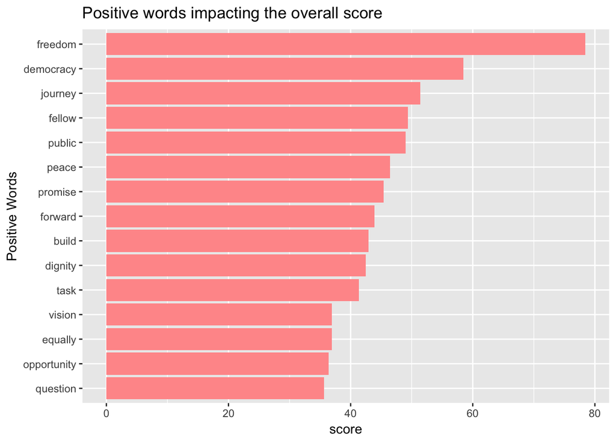

```r
# selecting positive words
word.score.positive <- summarise(group_by(dtm.idf.sentiment, word), score=sum(positive))
word.score.positive <- arrange(word.score.positive, desc(score))

# plotting
word.score.positive %>%
  arrange(score) %>%
  mutate(word = factor(word, word)) %>%
  top_n(15) %>%
  ggplot(aes(x=word, y=score)) +
    geom_bar(stat="identity", fill="#FF9999") +
    xlab("Positive Words") +
    ggtitle("Positive words impacting the overall score") +
    coord_flip()
```

The words “democracy” and “freedom” are widely used in all speeches and contribute to positive scores along with their lexicons (“peace”, “equally”).

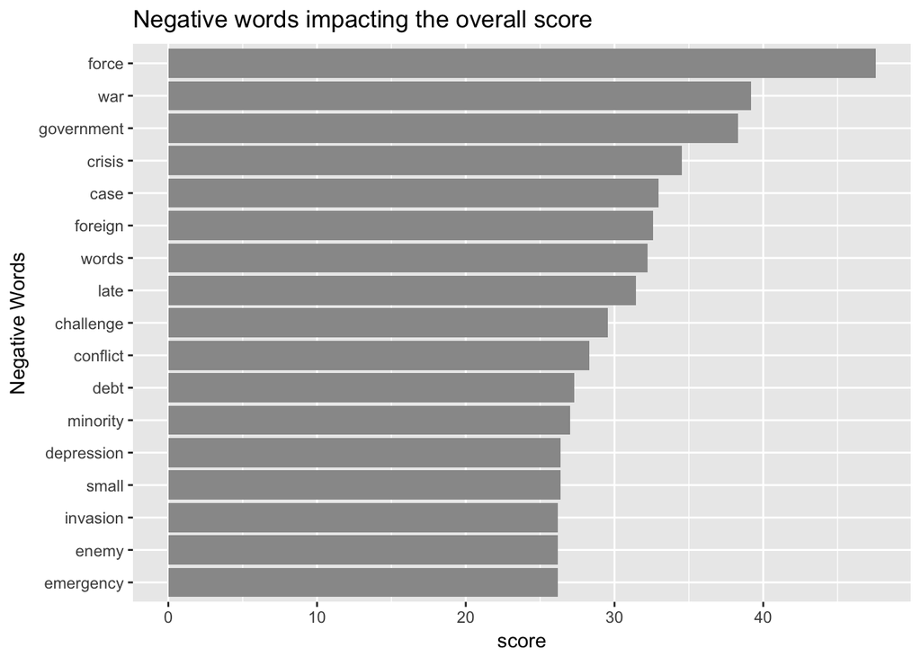

```r
# selecting negative words
word.score.negative <- summarise(group_by(dtm.idf.sentiment, word), score=sum(negative))
word.score.negative <- arrange(word.score.negative, desc(score))

# plotting
word.score.negative %>%
  arrange(score) %>%
  mutate(word = factor(word, word)) %>%
  top_n(15) %>%
  ggplot(aes(x=word, y=score)) +
    geom_bar(stat="identity", fill="#999999") +
    xlab("Negative Words") +
    ggtitle("Negative words impacting the overall score") +
    coord_flip()
```

Among with negative words the conflict’s lexicon is the more represented (“conflict”, “war”“,”force“,”enemy“,”invasion“,”force“). One possibility is that US presidents are more pessimistic about world conflicts after one term in office. At this stage of the analysis it’s only a hypothesis. Let’s compare negative words used by US presidents in their first and their second speeches.

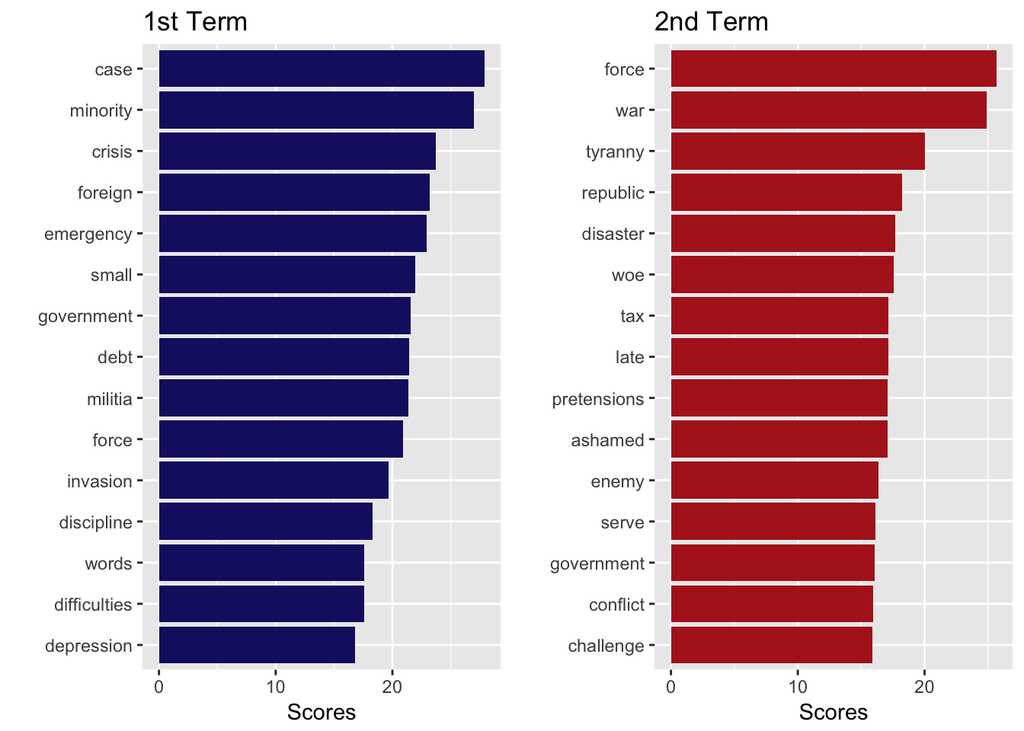

```r
# selecting negative words by term
word.negative.term <- summarise(group_by(dtm.idf.sentiment, word, term),
                                 score=sum(negative))

word.negative.term.1 <- filter(word.negative.term, term==1)
word.negative.term.1 <- arrange(word.negative.term.1, desc(score))
word.negative.term.2 <- filter(word.negative.term, term==2)
word.negative.term.2 <- arrange(word.negative.term.2, desc(score))

a <- ggplot(word.negative.term.1[1:15,],aes(x=reorder(word, score), y=score)) +
        geom_bar(stat="identity", fill="midnightblue") +
        xlab("") +
        ylab("Scores") +
        ggtitle("1st Term") +
        coord_flip()

b <- ggplot(word.negative.term.2[1:15,], aes(x=reorder(word, score), y=score)) +
        geom_bar(stat="identity", fill="firebrick") +
        xlab("") +
        ylab("Scores") +
        ggtitle("2nd Term") +
        coord_flip()

grid.arrange(a, b, nrow=1, ncol=2)
```

Indeed, the comparison of those two graphs show that the conflict lexicon is more present in the second speeches. Of course, that doesn’t mean that it is true for all presidents. I will let to the reader the opportunity to select a president and to display the negative terms associated with their first and their second inaugural speeches.

```r
# creating shiny app
ui <- fluidPage(selectInput(inputId = "data","", president.list),
                plotOutput(outputId = "plot")
)

server <- function(input, output) {
  # subset usefull tibble
  dfa <- reactive({
    summarise(group_by(dtm.idf.sentiment, word, term, president), score=sum(negative))
  })
  df <- reactive({
    filter(dfa(), president==input$data)
  })
  df1 <- reactive ({
    filter(df(), term==1) %>%
      arrange(desc(score))
  })
  df2 <- reactive ({
    filter(df(), term==2) %>%
      arrange(desc(score))
  })
  # df1 <- reactive ({
  #   arrange(df1(), desc(score))
  # })
  # df2 <- reactive ({
  #   arrange(df2(), desc(score))
  # })

  output$plot <- renderPlot({
    a <- ggplot(df1()[1:15,],aes(x=reorder(word, score), y=score)) +
        geom_bar(stat="identity", fill="midnightblue") +
        xlab("") +
        ylab("Scores") +
        ggtitle("1st Term") +
        coord_flip()
    b <- ggplot(df2()[1:15,], aes(x=reorder(word, score), y=score)) +
        geom_bar(stat="identity", fill="firebrick") +
        xlab("") +
        ylab("Scores") +
        ggtitle("2nd Term") +
        coord_flip()
    grid.arrange(a, b, nrow=1, ncol=2)
  })
}

shinyApp(ui = ui, server = server, options = list(height = 600))
```

Shiny applications not supported in static R Markdown documents

## Step 10 - Emotion Analysis

At at a higher levels we can display the emotions present in the speeches. Eight emotions will be displayed: trust, surprise, sadneess, joy feat, disgust, anticipation and anger. Those emotions are mapped with specific words in the same database as the one we used earlier. The goal of this section is to determine if any emotion is responsible for the less optimistic mindset of presidents at the beginning of their second term in office. The first panel will display those emotions for the first inaugural speech of the 16 presidents and the second panel for the second term.

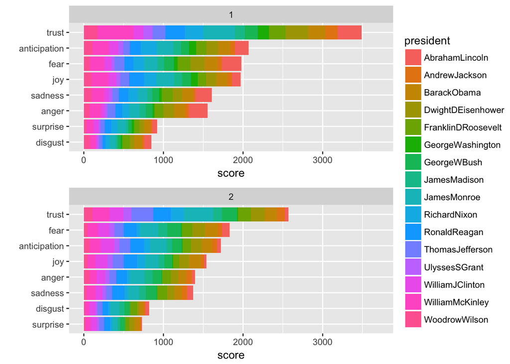

```r
# compute an emotion score for each speech and each of the 8 emotions
emotion.score <- summarise(group_by(dtm.idf.sentiment, term, president),
                           anger.score = sum(anger),
                           joy.score = sum(joy),
                           anticipation.score = sum(anticipation),
                           disgust.score = sum(disgust),
                           fear.score = sum(fear),
                           sadness.score = sum(sadness),
                           surprise.score = sum(surprise),
                           trust.score = sum(trust))
emotion.score <- gather(emotion.score, emotion, score,
               c(joy.score, anger.score, disgust.score, fear.score,
                 anticipation.score, sadness.score, surprise.score, sadness.score,
                 trust.score))
emotion.score$emotion <- substr(emotion.score$emotion, 0, nchar(emotion.score$emotion)-6)

emotion.score <- filter(emotion.score, term %in% c(1,2))

g <- ggplot(emotion.score[emotion.score$term==1,],
            aes(x=reorder(emotion,score), y=score, fill=president)) +
  geom_bar(stat="identity", position="stack") +
  coord_flip() +
  xlab("") +
  facet_wrap(~term, nrow=2) +
  expand_limits(y=c(0,3700))

h <- ggplot(emotion.score[emotion.score$term==2,],
            aes(x=reorder(emotion,score), y=score, fill=president)) +
  geom_bar(stat="identity", position="stack") +
  coord_flip() +
  xlab("") +
  facet_wrap(~term, nrow=2) +
  expand_limits(y=c(0,3700))

grid_arrange_shared_legend(g, h, ncol=1, nrow=2, position="right")
```

Trust is indeed a very important emotion, which takes the more space in all speeches, for all presidents and across time. The relative importance of those eight different emotions is almost conserved - they are almost in the same order in both graphs. However, one can notice that fear has gained importance in the second panel. Overall emotions are less present in the second speeches – trust has reduced by one fourth.

## Step 11 - Sentiment analysis when going through speeches

When reading speeches, we can affect a sentiment score to each part of the speech. In the graphs below each speech is separated in 20 sections of equal lengths. Then a sentiment score is computed for each section and plotted.

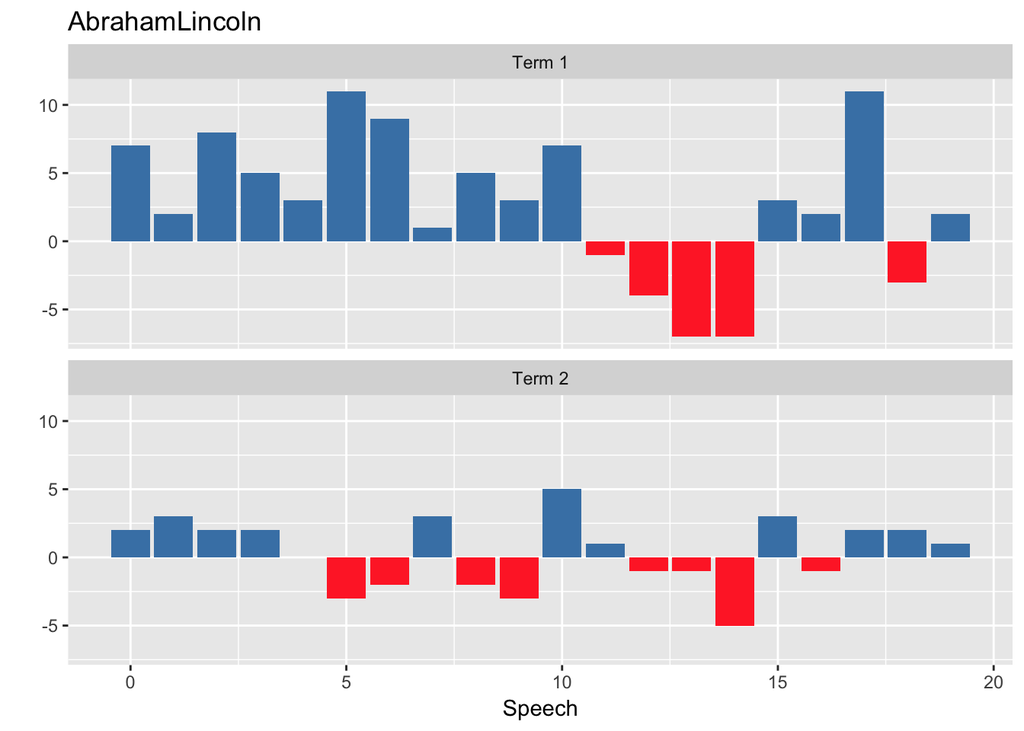

```r
a <- ggplot.flow(ff.all, "AbrahamLincoln")
a
```

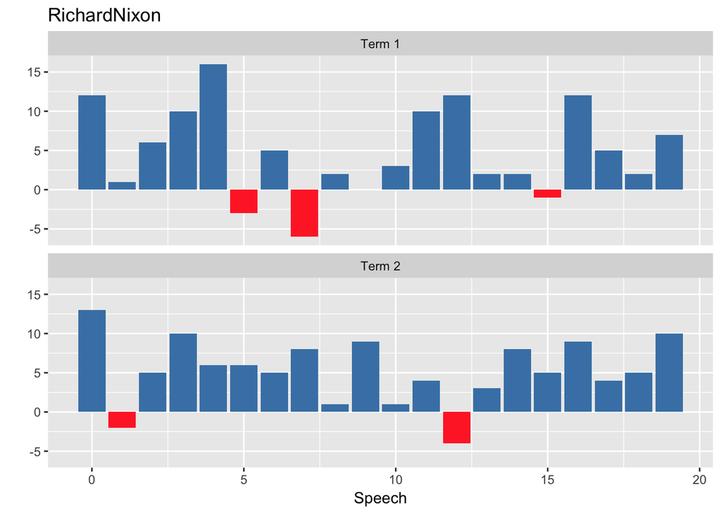

```r
b <- ggplot.flow(ff.all, "RichardNixon")
b
```

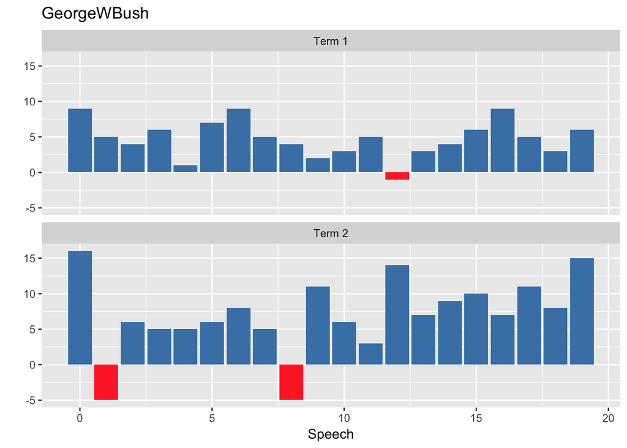

```r
c <- ggplot.flow(ff.all, "GeorgeWBush")
c
```

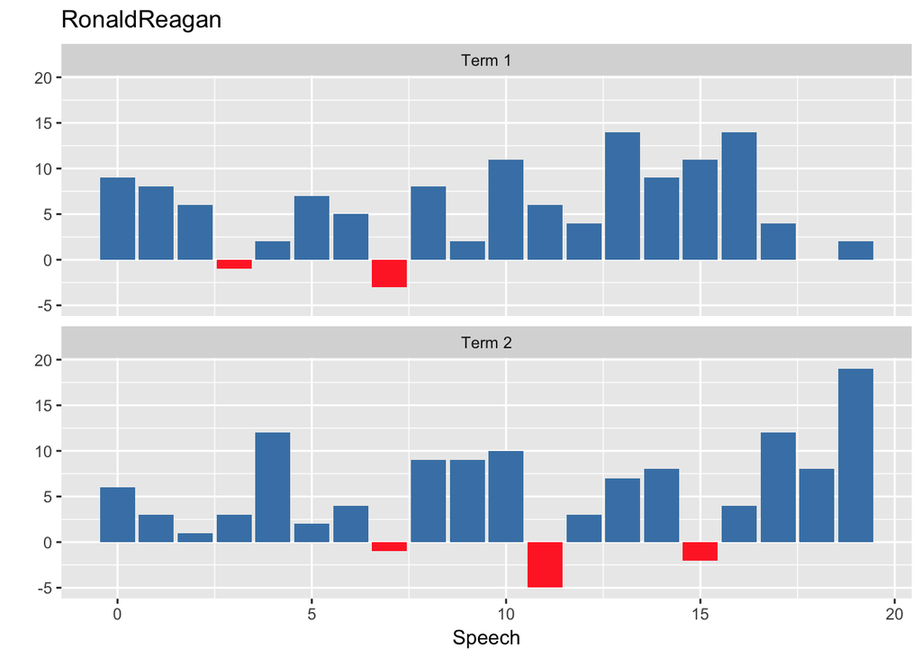

```r
d <- ggplot.flow(ff.all, "RonaldReagan")
d
```

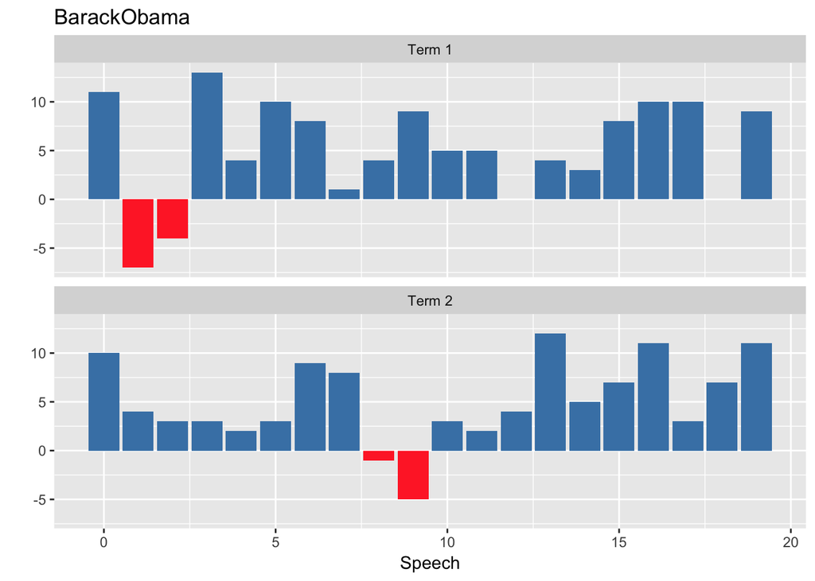

```r
e <- ggplot.flow(ff.all, "BarackObama")
e
```

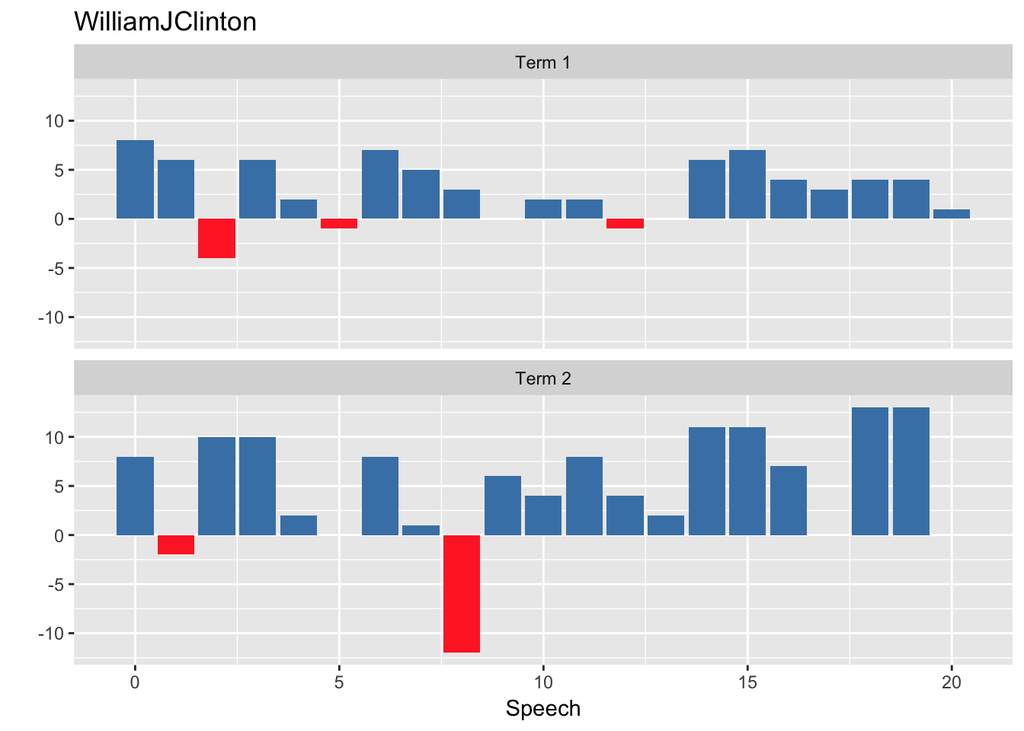

```r
f <- ggplot.flow(ff.all, "WilliamJClinton")
f
```

```r
#grid.arrange(a, b, c, d, e, ncol=1, nrow=5)
```

Overall, the number of negative sections seems to have increased from the 1st speech to the 2nd speech in this subset of presidents. However there is no strong pattern.

## Conclusion

Presidents tend to begin their second term in office with a more pessimistic speech - they are talking in a more negative way and some emotions like fear are more present in their speeches while trust seems to be overshadow. In addition, their speeches focus more on conflicts. We could make some assumptions on the reason why this is the case. Presidents may be more realistic about the impact they will have. They may be less moved because it is not the first time they are doing this type of speech. They may have a better understanding of what is at stake for their second mandate and, as a result be more precise about problems they will have to solve.

What would be interesting now is to try to understand which topics concerned presidents. To do that, we could use topic modelling. I won’t develop this analysis here. However, you can find below some starters for a LDA analysis and some visualization of the results - further interpretation of those results will be necessary.

## Future Developments - Topic Modeling

```r
## LDA Implementation

# subset dtm - 1§ president having done two terms in office
list1 <- paste0("inaug",president.list,"-1.txt")
list2 <- paste0("inaug",president.list,"-2.txt")
list <- c(list1, list2)
dtm.subset <- dtm[list,]

# set parameters for Gibbs sampling
burnin <- 4000
iter <- 2000
thin <- 500
seed <-list(2003,5,63,100001,765)
nstart <- 5
best <- TRUE
# number of topics
k <- 15

# run LDA using Gibbs sampling
ldaOut <-LDA(dtm.subset, k, method="Gibbs", control=list(nstart=nstart,
                                                 seed = seed, best=best,
                                                 burnin = burnin, iter = iter,
                                                 thin=thin))
```

```r
## LDA Results
# results
ldaOut.tidy <- tidy(ldaOut)

# associates each doc to one topic
ldaOut.topics <- as_tibble(topics(ldaOut))

# associates each doc to 2 topics
ldaOut.topics.2 <- as_tibble(topics(ldaOut, 2))

# top 20 terms in each topic
ldaOut.terms <- as_tibble(terms(ldaOut,20))

# probabilities associated with each topic assignment
topicProbabilities <- as_tibble(ldaOut@gamma)
```

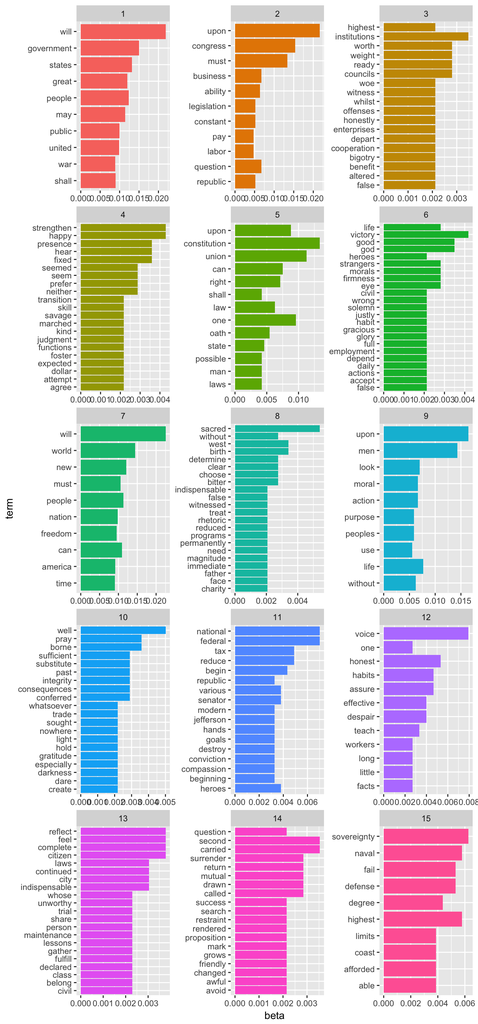

```r
## LDA Visualization

# Visualize top 10 terms per topic
ldaOut.top.terms <- ldaOut.tidy %>%
  group_by(topic) %>%
  top_n(10, beta) %>%
  ungroup() %>%
  arrange(topic, -beta)

ldaOut.top.terms %>%
  mutate(term = reorder(term, beta)) %>%
  ggplot(aes(term, beta, fill = factor(topic))) +
  geom_bar(stat = "identity", show.legend = FALSE) +
  facet_wrap(~ topic, scales = "free", ncol=3, nrow=5) +
  coord_flip()
```

```r
# Visualize Topics per speech
print(as.matrix(ldaOut.topics.2))
```

```
##      inaugAbrahamLincoln-1.txt inaugAndrewJackson-1.txt
## [1,]                         5                        1
## [2,]                         1                        2
##      inaugBarackObama-1.txt inaugDwightDEisenhower-1.txt
## [1,]                      7                            7
## [2,]                      9                            9
##      inaugFranklinDRoosevelt-1.txt inaugGeorgeWashington-1.txt
## [1,]                             7                           1
## [2,]                             9                           7
##      inaugGeorgeWBush-1.txt inaugJamesMadison-1.txt inaugJamesMonroe-1.txt
## [1,]                      7                       1                      1
## [2,]                      1                       3                     15
##      inaugRichardNixon-1.txt inaugRonaldReagan-1.txt
## [1,]                       7                       7
## [2,]                       8                      11
##      inaugThomasJefferson-1.txt inaugUlyssesSGrant-1.txt
## [1,]                          1                        1
## [2,]                          7                        2
##      inaugWilliamJClinton-1.txt inaugWilliamMcKinley-1.txt
## [1,]                          7                          1
## [2,]                         11                          2
##      inaugWoodrowWilson-1.txt inaugAbrahamLincoln-2.txt
## [1,]                        9                         1
## [2,]                        7                         7
##      inaugAndrewJackson-2.txt inaugBarackObama-2.txt
## [1,]                        1                      7
## [2,]                        7                     13
##      inaugDwightDEisenhower-2.txt inaugFranklinDRoosevelt-2.txt
## [1,]                            7                             7
## [2,]                            9                             9
##      inaugGeorgeWashington-2.txt inaugGeorgeWBush-2.txt
## [1,]                           1                      7
## [2,]                           5                      1
##      inaugJamesMadison-2.txt inaugJamesMonroe-2.txt
## [1,]                       1                      1
## [2,]                      14                     15
##      inaugRichardNixon-2.txt inaugRonaldReagan-2.txt
## [1,]                       7                       7
## [2,]                       1                      11
##      inaugThomasJefferson-2.txt inaugUlyssesSGrant-2.txt
## [1,]                          1                        1
## [2,]                          5                        7
##      inaugWilliamJClinton-2.txt inaugWilliamMcKinley-2.txt
## [1,]                          7                          1
## [2,]                          1                          2
##      inaugWoodrowWilson-2.txt
## [1,]                        7
## [2,]                        9
```